## Assignment 8

#### Due Thursday, November 14

The purpose of this assignment is to examine multiple separate statistical inference methods for proportions.

### Background

Chimpanzees (*Pan troglodytes*) are great apes and the closest related species to humans. In the wild, chimpanzees live in social groups, typically with many members of the groups closely related. While researchers have observed chimpanzees exhibit altruistic behavior in the wild, it has been a challenge to measure altruistic behavior in chimpanzees under controlled experimental conditions. However, a 2011 PNAS paper presents evidence of prosocial behavior among a group of chimpanzees living in a research center.

In one session of an experiment, one female chimpanzee, the *actor*, sits in a small room separated by a short distance from another chimpanzee, the *partner*. There is a window covered in wire mesh separating the chimpanzees so that they can see and hear all in the other room, but cannot touch each other. First, the actor is presented with 10 tokens, one at a time, with 5 of each of two colors in some random order. For a given session, one color is the *prosocial* while the other is the *selfish* color. When the actor takes the prosocial colored token, both the actor and partner receive food (a small piece of fruit wrapped in paper). When the actor takes the selfish token, only the actor receives food and the partner receives nothing. The purpose of these initial ten trials is to allow the chimpanzees the opportunity to see the consequences of each color choice.

After the ten training trials, the actor is presented with bucket that contains 30 tokens with 15 of each color. Two paper-wrapped fruit pieces are presented. The actor selects a colored token and either the actor only (selfish) or both actor and partner (prosocial) receive food. The selected token is replaced so the actor always has equal numbers of each color token to select. The actor’s choices are recorded over 30 trials.

In the full experiment, seven female chimpanzees served as actors for three sessions, each with different partner. These same chimpanzees were sometimes partners when another chimpanzee was the actor. For some sessions, the partner was selected from other chimpanzees in the social group at the research center, including the one male member of the group. Each actor also went through a session with no partner as a control. The researchers did not find any evidence that factors such as relatedness among chimpanzees, the identity of the partner, the choice of colors, dominance in the group hierarchy, or other similar potential confounding factors influenced the color choices that the actor made, but did find overall that each of the seven actors selected the prosocial token more often than the selfish token when in a session with a partner.

### 1

> Make a plot that displays the overall relative frequencies for making the prosocial choice separately for trials when a partner is present and when there is no partner. Use a thin line segment to visualize a 95% confidence interval, a slightly thicker line to visualize the interval one standard error above and below the point estimate, and a point at the point estimate. Add a dashed line at $p=0.5$. Label axes appropriately and add an informative title to the plot.

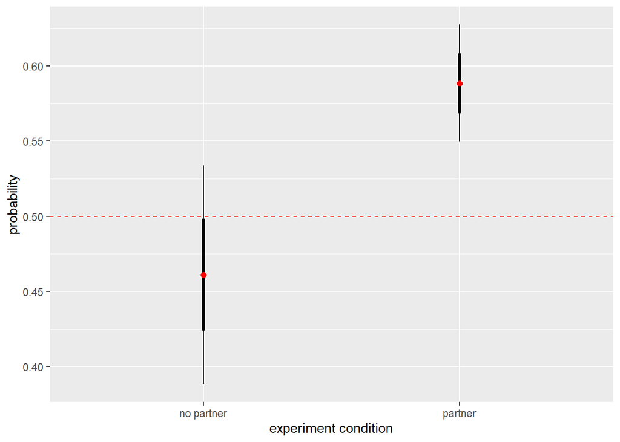

```r
chimps = read_csv("chimpanzee.csv") %>%
  mutate(with_partner = case_when(
    partner == "none" ~ "no partner",
    TRUE ~ "partner")) %>%
  select(actor,partner,with_partner,everything())

chimps1=chimps %>%
  group_by(with_partner) %>%
  mutate(n=prosocial+selfish)%>%
  summarise(prosocial=sum(prosocial),
            selfish=sum(selfish),
            n=prosocial+selfish,
            p_hat=prosocial/n,
            se=sqrt(p_hat*(1-p_hat)/n))

ggplot(chimps1,aes(x=with_partner,xend=with_partner))+
  geom_segment(aes(y=p_hat-1.96*se,yend=p_hat+1.96*se))+
  geom_segment(aes(y=p_hat-se,yend=p_hat+se),size=1.2)+
  geom_hline(yintercept = 0.5,color="red",linetype="dashed")+
  geom_point(aes(y=p_hat),color="red",size=2)+
  xlab("experiment condition")+
  ylab("probability")
```

### 2

```r
chimps2=chimps %>%
  filter(with_partner=="partner") %>%
  select(-with_partner) %>%
  group_by(actor) %>%
  summarise(prosocial=sum(prosocial),
            selfish=sum(selfish)) %>%
  mutate(n=prosocial+selfish,
         p_hat=prosocial/n,
         se_wald=sqrt( p_hat*(1-p_hat)/n),
         a_wald=p_hat-(qnorm(0.975)*se_wald),
         b_wald=p_hat+(qnorm(0.975)*se_wald),
         p_tilde = (prosocial+2)/(n+4),
         se_agresti = ( sqrt( p_tilde*(1-p_tilde)/n) ),
         a_agresti=p_tilde-(qnorm(0.975)*se_agresti),
         b_agresti=p_tilde+(qnorm(0.975)*se_agresti))
```

### 3

> Make a plot with two line segments for each actor chimpanzee, one displaying the Wald 95% confidence interval and one for the Agresti 95% confidence interval. Add a point representing the point estimate to each interval. Plot the line segments for each actor close to one another for easy comparison. Add a dashed line at $p=0.5$. Label axes appropriately and add an informative title to the plot.

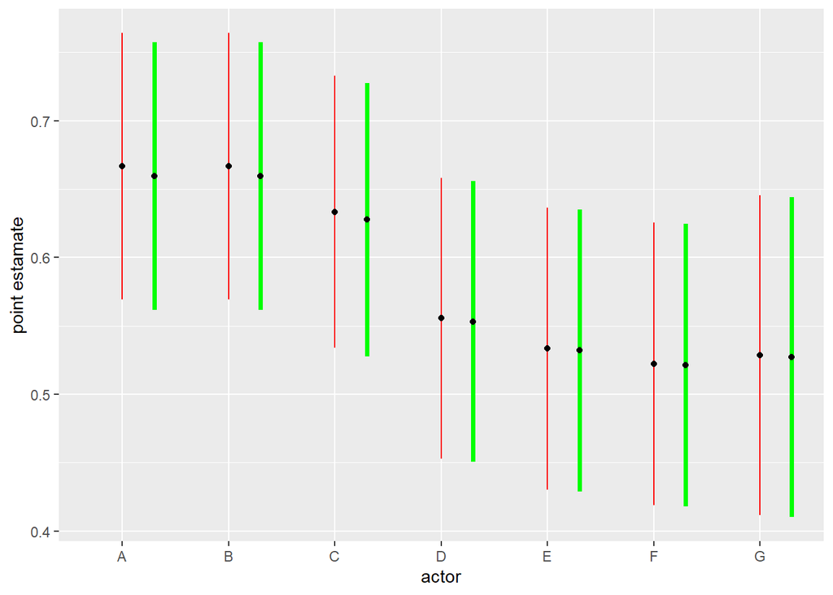

```r
chimps2 %>%
  ggplot()+
  geom_segment(aes(x=actor,xend=actor,y=a_wald, yend=b_wald),color="red")+
  geom_point(aes(x=actor,y=p_hat))+
  geom_segment(aes(x=as.integer(as.factor(actor))+0.3,
                   xend=as.integer(as.factor(actor))+0.3,
                   y=a_agresti,yend=b_agresti),color="green",size=1.3)+
  geom_point(aes(x=as.integer(as.factor(actor))+0.3,
                   y=p_tilde))+
  ylab("point estamate")
```

### 4

> Repeat Problem 2 for the data for trials without partners (for the six chimpanzees involved in such trials).

```r
chimps4=chimps %>%
  filter(with_partner=="no partner") %>%
  select(-with_partner) %>%
  group_by(actor) %>%
  summarise(prosocial=sum(prosocial),
            selfish=sum(selfish)) %>%
  mutate(n=prosocial+selfish,
         p_hat=prosocial/n,
         se_wald=sqrt( p_hat*(1-p_hat)/n),
         a_wald=p_hat-(qnorm(0.975)*se_wald),
         b_wald=p_hat+(qnorm(0.975)*se_wald),
         p_tilde = (prosocial+2)/(n+4),
         se_agresti = sqrt( p_tilde*(1-p_tilde)/n),
         a_agresti=p_tilde-(qnorm(0.975)*se_agresti),
         b_agresti=p_tilde+(qnorm(0.975)*se_agresti))
```

### 5

> Repeat Problem 3 for the data for trial without partners.

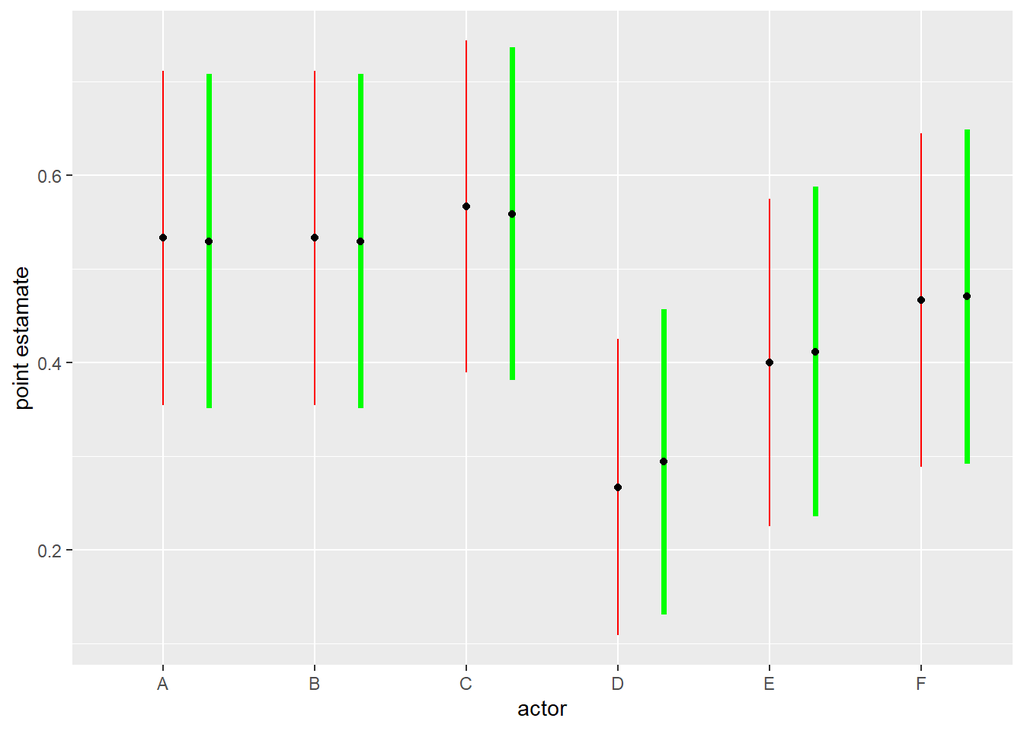

```r
chimps4 %>%
  ggplot()+
  geom_segment(aes(x=actor,xend=actor,y=a_wald, yend=b_wald),color="red")+
  geom_point(aes(x=actor,y=p_hat))+
  geom_segment(aes(x=as.integer(as.factor(actor))+0.3,
                   xend=as.integer(as.factor(actor))+0.3,
                   y=a_agresti,yend=b_agresti),color="green",size=1.3)+
  geom_point(aes(x=as.integer(as.factor(actor))+0.3,
                   y=p_tilde))+
  ylab("point estamate")
```

### 6

> Assume a model in which all trials with a partner present are assumed independent with the same prosocial choice probability $p$ for all chimpanzees. Conduct a hypothesis test for $p=0.5$ versus a two-sided alternative. Include all steps as in examples in lecture, finishing with an interpretation of the confidence interval in context of the setting of the data.

```r
##null: p=0.5
##alt: p !=0.5
df_6 = chimps %>%
  filter(with_partner=="partner") %>%
  summarise(prosocial=sum(prosocial),
            selfish=sum(selfish),
            n=prosocial+selfish,
            p_mean=prosocial/n,
            p = 0.5,
            se = sqrt(p*(1-p)/n),
            z = (p-p_mean)/se,
            p_value = 2*pnorm(-abs(z)))

df_6$p_value
```

```
## [1] 1.226675e-05
```

```r
pbinom(df_6$selfish,df_6$n,0.5)*2
```

```
## [1] 1.405895e-05
```

```r
df_6$p_mean+1.96*df_6$se
```

```
## [1] 0.6282036
```

```r
df_6$p_mean-1.96*df_6$se
```

```
## [1] 0.5488455
```

```r
### both p value and confidence interval shows evidence that we should reject the null hypothsis, p value<0.05 and the confidense interval is between 0.6282036 and 0.5488455, which is higher than the 0.5.
```

### 7

> Repeat Problem 6 using the data in trials without a partner.

```r
df_7 = chimps %>%
  filter(with_partner=="no partner") %>%
  summarise(prosocial=sum(prosocial),
            selfish=sum(selfish),
            n=prosocial+selfish,
            p_mean=mean(prosocial/n),
            p = 0.5,
            se = sqrt(p*(1-p)/n),
            z = (p-p_mean)/se,
            p_value = 2*pnorm(-abs(z)))

df_7$p_value
```

```
## [1] 0.2967175
```

```r
pbinom(df_7$prosocial,df_7$n,0.5)*2
```

```
## [1] 0.3325791
```

```r
df_7$p_mean+1.96*df_7$se
```

```
## [1] 0.534156
```

```r
df_7$p_mean-1.96*df_7$se
```

```
## [1] 0.3880662
```

### 8

> Assuming the model from problem 6, compute the Wald and Agresti confidence intervals for $p$.

```r
p_hat=359/610
se_wald=sqrt(p_hat*(1-p_hat)/610)
p_tilde=361/614
se_agresti=sqrt(p_tilde*(1-p_tilde)/610)

p_hat+1.96*se_wald
```

```
## [1] 0.6275768
```

```r
p_hat-1.96*se_wald
```

```
## [1] 0.5494724
```

```r
p_tilde+1.96*se_agresti
```

```
## [1] 0.6270083
```

```r
p_tilde-1.96*se_agresti
```

```
## [1] 0.5488875
```